# 2023年度报告-收入分析

使用em的业绩报告数据。

## 营业收入

### 历年合计及增长

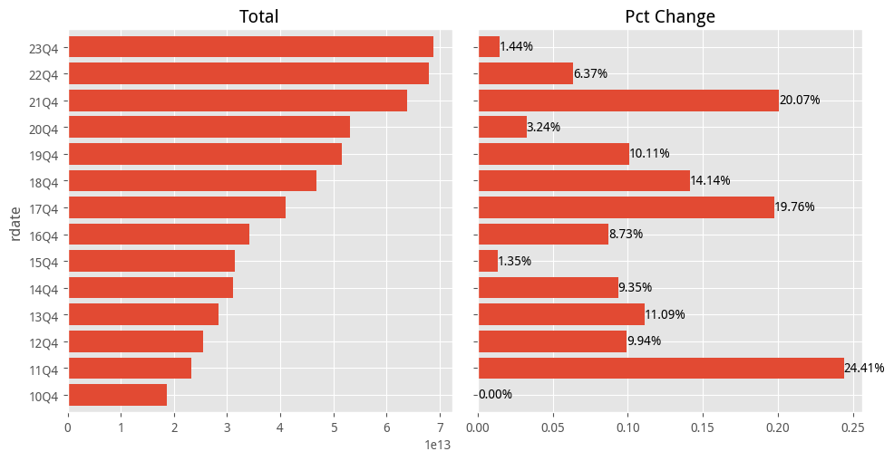

- 2023年收入仍保持增长，但处于历史低位。仅仅略高于2015年。
- 历史上的高位是2011年，2021年，和2017年。

|  | sum | mean | median | min | max |
| --- | --- | --- | --- | --- | --- |
| 0 | [中国石化](https://data.eastmoney.com/stockdata/600028.html) | [中国石化](https://data.eastmoney.com/stockdata/600028.html) | [中国石化](https://data.eastmoney.com/stockdata/600028.html) | [中国石化](https://data.eastmoney.com/stockdata/600028.html) | [中国石化](https://data.eastmoney.com/stockdata/600028.html) |
| 1 | [中国石油](https://data.eastmoney.com/stockdata/601857.html) | [中国石油](https://data.eastmoney.com/stockdata/601857.html) | [中国石油](https://data.eastmoney.com/stockdata/601857.html) | [中国石油](https://data.eastmoney.com/stockdata/601857.html) | [中国石油](https://data.eastmoney.com/stockdata/601857.html) |
| 2 | [中国建筑](https://data.eastmoney.com/stockdata/601668.html) | [中国建筑](https://data.eastmoney.com/stockdata/601668.html) | [中国建筑](https://data.eastmoney.com/stockdata/601668.html) | [中国中铁](https://data.eastmoney.com/stockdata/601390.html) | [中国建筑](https://data.eastmoney.com/stockdata/601668.html) |
| 3 | [中国中铁](https://data.eastmoney.com/stockdata/601390.html) | [中国中铁](https://data.eastmoney.com/stockdata/601390.html) | [中国平安](https://data.eastmoney.com/stockdata/601318.html) | [中国铁建](https://data.eastmoney.com/stockdata/601186.html) | [中国中铁](https://data.eastmoney.com/stockdata/601390.html) |
| 4 | [中国铁建](https://data.eastmoney.com/stockdata/601186.html) | [中国铁建](https://data.eastmoney.com/stockdata/601186.html) | [上汽集团](https://data.eastmoney.com/stockdata/600104.html) | [中国人寿](https://data.eastmoney.com/stockdata/601628.html) | [中国平安](https://data.eastmoney.com/stockdata/601318.html) |
| 5 | [中国平安](https://data.eastmoney.com/stockdata/601318.html) | [中国平安](https://data.eastmoney.com/stockdata/601318.html) | [工商银行](https://data.eastmoney.com/stockdata/601398.html) | [工商银行](https://data.eastmoney.com/stockdata/601398.html) | [中国铁建](https://data.eastmoney.com/stockdata/601186.html) |
| 6 | [工商银行](https://data.eastmoney.com/stockdata/601398.html) | [工商银行](https://data.eastmoney.com/stockdata/601398.html) | [中国中铁](https://data.eastmoney.com/stockdata/601390.html) | [中国建筑](https://data.eastmoney.com/stockdata/601668.html) | [工商银行](https://data.eastmoney.com/stockdata/601398.html) |
| 7 | [上汽集团](https://data.eastmoney.com/stockdata/600104.html) | [上汽集团](https://data.eastmoney.com/stockdata/600104.html) | [中国铁建](https://data.eastmoney.com/stockdata/601186.html) | [上汽集团](https://data.eastmoney.com/stockdata/600104.html) | [上汽集团](https://data.eastmoney.com/stockdata/600104.html) |
| 8 | [建设银行](https://data.eastmoney.com/stockdata/601939.html) | [建设银行](https://data.eastmoney.com/stockdata/601939.html) | [建设银行](https://data.eastmoney.com/stockdata/601939.html) | [建设银行](https://data.eastmoney.com/stockdata/601939.html) | [中国人寿](https://data.eastmoney.com/stockdata/601628.html) |
| 9 | [中国人寿](https://data.eastmoney.com/stockdata/601628.html) | [中国人寿](https://data.eastmoney.com/stockdata/601628.html) | [中国人寿](https://data.eastmoney.com/stockdata/601628.html) | [农业银行](https://data.eastmoney.com/stockdata/601288.html) | [建发股份](https://data.eastmoney.com/stockdata/600153.html) |
| 10 | [农业银行](https://data.eastmoney.com/stockdata/601288.html) | [农业银行](https://data.eastmoney.com/stockdata/601288.html) | [农业银行](https://data.eastmoney.com/stockdata/601288.html) | [中国银行](https://data.eastmoney.com/stockdata/601988.html) | [建设银行](https://data.eastmoney.com/stockdata/601939.html) |
| 11 | [中国交建](https://data.eastmoney.com/stockdata/601800.html) | [中国交建](https://data.eastmoney.com/stockdata/601800.html) | [中国银行](https://data.eastmoney.com/stockdata/601988.html) | [中国交建](https://data.eastmoney.com/stockdata/601800.html) | [中国交建](https://data.eastmoney.com/stockdata/601800.html) |
| 12 | [中国银行](https://data.eastmoney.com/stockdata/601988.html) | [中国银行](https://data.eastmoney.com/stockdata/601988.html) | [中国交建](https://data.eastmoney.com/stockdata/601800.html) | [工业富联](https://data.eastmoney.com/stockdata/601138.html) | [农业银行](https://data.eastmoney.com/stockdata/601288.html) |
| 13 | [中国电信](https://data.eastmoney.com/stockdata/601728.html) | [工业富联](https://data.eastmoney.com/stockdata/601138.html) | [工业富联](https://data.eastmoney.com/stockdata/601138.html) | [中国电信](https://data.eastmoney.com/stockdata/601728.html) | [中国中冶](https://data.eastmoney.com/stockdata/601618.html) |
| 14 | [中国中冶](https://data.eastmoney.com/stockdata/601618.html) | [中国电信](https://data.eastmoney.com/stockdata/601728.html) | [中国电信](https://data.eastmoney.com/stockdata/601728.html) | [中国中冶](https://data.eastmoney.com/stockdata/601618.html) | [中国银行](https://data.eastmoney.com/stockdata/601988.html) |
| 15 | [建发股份](https://data.eastmoney.com/stockdata/600153.html) | [中国中冶](https://data.eastmoney.com/stockdata/601618.html) | [中国太保](https://data.eastmoney.com/stockdata/601601.html) | [中国平安](https://data.eastmoney.com/stockdata/601318.html) | [中国电建](https://data.eastmoney.com/stockdata/601669.html) |
| 16 | [中国电建](https://data.eastmoney.com/stockdata/601669.html) | [建发股份](https://data.eastmoney.com/stockdata/600153.html) | [中国联通](https://data.eastmoney.com/stockdata/600050.html) | [中国联通](https://data.eastmoney.com/stockdata/600050.html) | [比亚迪](https://data.eastmoney.com/stockdata/002594.html) |
| 17 | [中国联通](https://data.eastmoney.com/stockdata/600050.html) | [中国电建](https://data.eastmoney.com/stockdata/601669.html) | [绿地控股](https://data.eastmoney.com/stockdata/600606.html) | [宝钢股份](https://data.eastmoney.com/stockdata/600019.html) | [物产中大](https://data.eastmoney.com/stockdata/600704.html) |
| 18 | [中国太保](https://data.eastmoney.com/stockdata/601601.html) | [中国联通](https://data.eastmoney.com/stockdata/600050.html) | [宝钢股份](https://data.eastmoney.com/stockdata/600019.html) | [中国神华](https://data.eastmoney.com/stockdata/601088.html) | [绿地控股](https://data.eastmoney.com/stockdata/600606.html) |
| 19 | [物产中大](https://data.eastmoney.com/stockdata/600704.html) | [中国太保](https://data.eastmoney.com/stockdata/601601.html) | [中国电建](https://data.eastmoney.com/stockdata/601669.html) | [中国海油](https://data.eastmoney.com/stockdata/600938.html) | [厦门象屿](https://data.eastmoney.com/stockdata/600057.html) |

### 总体变化

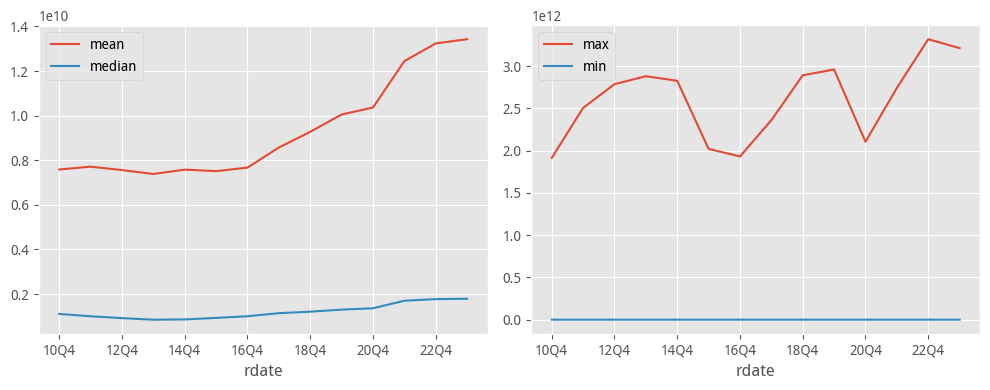

- 均值和中位数整体趋势仍在增长。中位数增长更低，说明强者增长更大。
- 收入极值出现下降。

### 每年前20

| rdate | 10Q4 | 11Q4 | 12Q4 | 13Q4 | 14Q4 | 15Q4 | 16Q4 | 17Q4 | 18Q4 | 19Q4 | 20Q4 | 21Q4 | 22Q4 | 23Q4 |
| --- | --- | --- | --- | --- | --- | --- | --- | --- | --- | --- | --- | --- | --- | --- |
| 0 | [中国石化](https://data.eastmoney.com/stockdata/600028.html) | [中国石化](https://data.eastmoney.com/stockdata/600028.html) | [中国石化](https://data.eastmoney.com/stockdata/600028.html) | [中国石化](https://data.eastmoney.com/stockdata/600028.html) | [中国石化](https://data.eastmoney.com/stockdata/600028.html) | [中国石化](https://data.eastmoney.com/stockdata/600028.html) | [中国石化](https://data.eastmoney.com/stockdata/600028.html) | [中国石化](https://data.eastmoney.com/stockdata/600028.html) | [中国石化](https://data.eastmoney.com/stockdata/600028.html) | [中国石化](https://data.eastmoney.com/stockdata/600028.html) | [中国石化](https://data.eastmoney.com/stockdata/600028.html) | [中国石化](https://data.eastmoney.com/stockdata/600028.html) | [中国石化](https://data.eastmoney.com/stockdata/600028.html) | [中国石化](https://data.eastmoney.com/stockdata/600028.html) |
| 1 | [中国石油](https://data.eastmoney.com/stockdata/601857.html) | [中国石油](https://data.eastmoney.com/stockdata/601857.html) | [中国石油](https://data.eastmoney.com/stockdata/601857.html) | [中国石油](https://data.eastmoney.com/stockdata/601857.html) | [中国石油](https://data.eastmoney.com/stockdata/601857.html) | [中国石油](https://data.eastmoney.com/stockdata/601857.html) | [中国石油](https://data.eastmoney.com/stockdata/601857.html) | [中国石油](https://data.eastmoney.com/stockdata/601857.html) | [中国石油](https://data.eastmoney.com/stockdata/601857.html) | [中国石油](https://data.eastmoney.com/stockdata/601857.html) | [中国石油](https://data.eastmoney.com/stockdata/601857.html) | [中国石油](https://data.eastmoney.com/stockdata/601857.html) | [中国石油](https://data.eastmoney.com/stockdata/601857.html) | [中国石油](https://data.eastmoney.com/stockdata/601857.html) |
| 2 | [中国中铁](https://data.eastmoney.com/stockdata/601390.html) | [中国建筑](https://data.eastmoney.com/stockdata/601668.html) | [中国建筑](https://data.eastmoney.com/stockdata/601668.html) | [中国建筑](https://data.eastmoney.com/stockdata/601668.html) | [中国建筑](https://data.eastmoney.com/stockdata/601668.html) | [中国建筑](https://data.eastmoney.com/stockdata/601668.html) | [中国建筑](https://data.eastmoney.com/stockdata/601668.html) | [中国建筑](https://data.eastmoney.com/stockdata/601668.html) | [中国建筑](https://data.eastmoney.com/stockdata/601668.html) | [中国建筑](https://data.eastmoney.com/stockdata/601668.html) | [中国建筑](https://data.eastmoney.com/stockdata/601668.html) | [中国建筑](https://data.eastmoney.com/stockdata/601668.html) | [中国建筑](https://data.eastmoney.com/stockdata/601668.html) | [中国建筑](https://data.eastmoney.com/stockdata/601668.html) |
| 3 | [中国铁建](https://data.eastmoney.com/stockdata/601186.html) | [工商银行](https://data.eastmoney.com/stockdata/601398.html) | [工商银行](https://data.eastmoney.com/stockdata/601398.html) | [工商银行](https://data.eastmoney.com/stockdata/601398.html) | [工商银行](https://data.eastmoney.com/stockdata/601398.html) | [工商银行](https://data.eastmoney.com/stockdata/601398.html) | [上汽集团](https://data.eastmoney.com/stockdata/600104.html) | [中国平安](https://data.eastmoney.com/stockdata/601318.html) | [中国平安](https://data.eastmoney.com/stockdata/601318.html) | [中国平安](https://data.eastmoney.com/stockdata/601318.html) | [中国平安](https://data.eastmoney.com/stockdata/601318.html) | [中国平安](https://data.eastmoney.com/stockdata/601318.html) | [中国中铁](https://data.eastmoney.com/stockdata/601390.html) | [中国中铁](https://data.eastmoney.com/stockdata/601390.html) |
| 4 | [中国人寿](https://data.eastmoney.com/stockdata/601628.html) | [中国中铁](https://data.eastmoney.com/stockdata/601390.html) | [中国铁建](https://data.eastmoney.com/stockdata/601186.html) | [中国铁建](https://data.eastmoney.com/stockdata/601186.html) | [上汽集团](https://data.eastmoney.com/stockdata/600104.html) | [上汽集团](https://data.eastmoney.com/stockdata/600104.html) | [中国平安](https://data.eastmoney.com/stockdata/601318.html) | [上汽集团](https://data.eastmoney.com/stockdata/600104.html) | [上汽集团](https://data.eastmoney.com/stockdata/600104.html) | [工商银行](https://data.eastmoney.com/stockdata/601398.html) | [中国中铁](https://data.eastmoney.com/stockdata/601390.html) | [中国中铁](https://data.eastmoney.com/stockdata/601390.html) | [中国铁建](https://data.eastmoney.com/stockdata/601186.html) | [中国铁建](https://data.eastmoney.com/stockdata/601186.html) |
| 5 | [工商银行](https://data.eastmoney.com/stockdata/601398.html) | [中国铁建](https://data.eastmoney.com/stockdata/601186.html) | [中国中铁](https://data.eastmoney.com/stockdata/601390.html) | [上汽集团](https://data.eastmoney.com/stockdata/600104.html) | [中国中铁](https://data.eastmoney.com/stockdata/601390.html) | [中国中铁](https://data.eastmoney.com/stockdata/601390.html) | [工商银行](https://data.eastmoney.com/stockdata/601398.html) | [工商银行](https://data.eastmoney.com/stockdata/601398.html) | [工商银行](https://data.eastmoney.com/stockdata/601398.html) | [中国中铁](https://data.eastmoney.com/stockdata/601390.html) | [中国铁建](https://data.eastmoney.com/stockdata/601186.html) | [中国铁建](https://data.eastmoney.com/stockdata/601186.html) | [中国平安](https://data.eastmoney.com/stockdata/601318.html) | [中国平安](https://data.eastmoney.com/stockdata/601318.html) |
| 6 | [中国建筑](https://data.eastmoney.com/stockdata/601668.html) | [上汽集团](https://data.eastmoney.com/stockdata/600104.html) | [上汽集团](https://data.eastmoney.com/stockdata/600104.html) | [中国中铁](https://data.eastmoney.com/stockdata/601390.html) | [中国铁建](https://data.eastmoney.com/stockdata/601186.html) | [中国平安](https://data.eastmoney.com/stockdata/601318.html) | [中国中铁](https://data.eastmoney.com/stockdata/601390.html) | [中国中铁](https://data.eastmoney.com/stockdata/601390.html) | [中国中铁](https://data.eastmoney.com/stockdata/601390.html) | [上汽集团](https://data.eastmoney.com/stockdata/600104.html) | [工商银行](https://data.eastmoney.com/stockdata/601398.html) | [工商银行](https://data.eastmoney.com/stockdata/601398.html) | [工商银行](https://data.eastmoney.com/stockdata/601398.html) | [工商银行](https://data.eastmoney.com/stockdata/601398.html) |
| 7 | [上汽集团](https://data.eastmoney.com/stockdata/600104.html) | [建设银行](https://data.eastmoney.com/stockdata/601939.html) | [建设银行](https://data.eastmoney.com/stockdata/601939.html) | [建设银行](https://data.eastmoney.com/stockdata/601939.html) | [建设银行](https://data.eastmoney.com/stockdata/601939.html) | [建设银行](https://data.eastmoney.com/stockdata/601939.html) | [中国铁建](https://data.eastmoney.com/stockdata/601186.html) | [中国铁建](https://data.eastmoney.com/stockdata/601186.html) | [中国铁建](https://data.eastmoney.com/stockdata/601186.html) | [中国铁建](https://data.eastmoney.com/stockdata/601186.html) | [中国人寿](https://data.eastmoney.com/stockdata/601628.html) | [中国人寿](https://data.eastmoney.com/stockdata/601628.html) | [建发股份](https://data.eastmoney.com/stockdata/600153.html) | [中国人寿](https://data.eastmoney.com/stockdata/601628.html) |
| 8 | [建设银行](https://data.eastmoney.com/stockdata/601939.html) | [中国人寿](https://data.eastmoney.com/stockdata/601628.html) | [农业银行](https://data.eastmoney.com/stockdata/601288.html) | [农业银行](https://data.eastmoney.com/stockdata/601288.html) | [农业银行](https://data.eastmoney.com/stockdata/601288.html) | [中国铁建](https://data.eastmoney.com/stockdata/601186.html) | [建设银行](https://data.eastmoney.com/stockdata/601939.html) | [中国人寿](https://data.eastmoney.com/stockdata/601628.html) | [建设银行](https://data.eastmoney.com/stockdata/601939.html) | [中国人寿](https://data.eastmoney.com/stockdata/601628.html) | [建设银行](https://data.eastmoney.com/stockdata/601939.html) | [建设银行](https://data.eastmoney.com/stockdata/601939.html) | [中国人寿](https://data.eastmoney.com/stockdata/601628.html) | [建设银行](https://data.eastmoney.com/stockdata/601939.html) |
| 9 | [农业银行](https://data.eastmoney.com/stockdata/601288.html) | [农业银行](https://data.eastmoney.com/stockdata/601288.html) | [中国人寿](https://data.eastmoney.com/stockdata/601628.html) | [中国人寿](https://data.eastmoney.com/stockdata/601628.html) | [中国平安](https://data.eastmoney.com/stockdata/601318.html) | [农业银行](https://data.eastmoney.com/stockdata/601288.html) | [中国人寿](https://data.eastmoney.com/stockdata/601628.html) | [建设银行](https://data.eastmoney.com/stockdata/601939.html) | [中国人寿](https://data.eastmoney.com/stockdata/601628.html) | [建设银行](https://data.eastmoney.com/stockdata/601939.html) | [上汽集团](https://data.eastmoney.com/stockdata/600104.html) | [上汽集团](https://data.eastmoney.com/stockdata/600104.html) | [建设银行](https://data.eastmoney.com/stockdata/601939.html) | [建发股份](https://data.eastmoney.com/stockdata/600153.html) |
| 10 | [中国银行](https://data.eastmoney.com/stockdata/601988.html) | [中国银行](https://data.eastmoney.com/stockdata/601988.html) | [中国银行](https://data.eastmoney.com/stockdata/601988.html) | [中国银行](https://data.eastmoney.com/stockdata/601988.html) | [中国银行](https://data.eastmoney.com/stockdata/601988.html) | [中国人寿](https://data.eastmoney.com/stockdata/601628.html) | [农业银行](https://data.eastmoney.com/stockdata/601288.html) | [农业银行](https://data.eastmoney.com/stockdata/601288.html) | [农业银行](https://data.eastmoney.com/stockdata/601288.html) | [农业银行](https://data.eastmoney.com/stockdata/601288.html) | [农业银行](https://data.eastmoney.com/stockdata/601288.html) | [农业银行](https://data.eastmoney.com/stockdata/601288.html) | [上汽集团](https://data.eastmoney.com/stockdata/600104.html) | [中国交建](https://data.eastmoney.com/stockdata/601800.html) |
| 11 | [中国交建](https://data.eastmoney.com/stockdata/601800.html) | [中国交建](https://data.eastmoney.com/stockdata/601800.html) | [中国平安](https://data.eastmoney.com/stockdata/601318.html) | [中国平安](https://data.eastmoney.com/stockdata/601318.html) | [中国人寿](https://data.eastmoney.com/stockdata/601628.html) | [中国银行](https://data.eastmoney.com/stockdata/601988.html) | [中国银行](https://data.eastmoney.com/stockdata/601988.html) | [中国银行](https://data.eastmoney.com/stockdata/601988.html) | [中国银行](https://data.eastmoney.com/stockdata/601988.html) | [中国交建](https://data.eastmoney.com/stockdata/601800.html) | [中国交建](https://data.eastmoney.com/stockdata/601800.html) | [建发股份](https://data.eastmoney.com/stockdata/600153.html) | [中国交建](https://data.eastmoney.com/stockdata/601800.html) | [上汽集团](https://data.eastmoney.com/stockdata/600104.html) |
| 12 | [中国电信](https://data.eastmoney.com/stockdata/601728.html) | [中国电信](https://data.eastmoney.com/stockdata/601728.html) | [中国交建](https://data.eastmoney.com/stockdata/601800.html) | [中国交建](https://data.eastmoney.com/stockdata/601800.html) | [中国交建](https://data.eastmoney.com/stockdata/601800.html) | [中国交建](https://data.eastmoney.com/stockdata/601800.html) | [中国交建](https://data.eastmoney.com/stockdata/601800.html) | [中国交建](https://data.eastmoney.com/stockdata/601800.html) | [中国交建](https://data.eastmoney.com/stockdata/601800.html) | [中国银行](https://data.eastmoney.com/stockdata/601988.html) | [中国银行](https://data.eastmoney.com/stockdata/601988.html) | [中国交建](https://data.eastmoney.com/stockdata/601800.html) | [农业银行](https://data.eastmoney.com/stockdata/601288.html) | [农业银行](https://data.eastmoney.com/stockdata/601288.html) |
| 13 | [中国中冶](https://data.eastmoney.com/stockdata/601618.html) | [中国平安](https://data.eastmoney.com/stockdata/601318.html) | [中国电信](https://data.eastmoney.com/stockdata/601728.html) | [中国电信](https://data.eastmoney.com/stockdata/601728.html) | [中国电信](https://data.eastmoney.com/stockdata/601728.html) | [中国电信](https://data.eastmoney.com/stockdata/601728.html) | [中国电信](https://data.eastmoney.com/stockdata/601728.html) | [中国电信](https://data.eastmoney.com/stockdata/601728.html) | [工业富联](https://data.eastmoney.com/stockdata/601138.html) | [绿地控股](https://data.eastmoney.com/stockdata/600606.html) | [绿地控股](https://data.eastmoney.com/stockdata/600606.html) | [中国银行](https://data.eastmoney.com/stockdata/601988.html) | [中国中冶](https://data.eastmoney.com/stockdata/601618.html) | [中国中冶](https://data.eastmoney.com/stockdata/601618.html) |
| 14 | [宝钢股份](https://data.eastmoney.com/stockdata/600019.html) | [中国中冶](https://data.eastmoney.com/stockdata/601618.html) | [中国联通](https://data.eastmoney.com/stockdata/600050.html) | [中国联通](https://data.eastmoney.com/stockdata/600050.html) | [中国联通](https://data.eastmoney.com/stockdata/600050.html) | [中国联通](https://data.eastmoney.com/stockdata/600050.html) | [中国联通](https://data.eastmoney.com/stockdata/600050.html) | [工业富联](https://data.eastmoney.com/stockdata/601138.html) | [中国电信](https://data.eastmoney.com/stockdata/601728.html) | [工业富联](https://data.eastmoney.com/stockdata/601138.html) | [建发股份](https://data.eastmoney.com/stockdata/600153.html) | [中国电建](https://data.eastmoney.com/stockdata/601669.html) | [中国银行](https://data.eastmoney.com/stockdata/601988.html) | [中国银行](https://data.eastmoney.com/stockdata/601988.html) |
| 15 | [中国平安](https://data.eastmoney.com/stockdata/601318.html) | [宝钢股份](https://data.eastmoney.com/stockdata/600019.html) | [中国神华](https://data.eastmoney.com/stockdata/601088.html) | [中国神华](https://data.eastmoney.com/stockdata/601088.html) | [绿地控股](https://data.eastmoney.com/stockdata/600606.html) | [工业富联](https://data.eastmoney.com/stockdata/601138.html) | [工业富联](https://data.eastmoney.com/stockdata/601138.html) | [中国太保](https://data.eastmoney.com/stockdata/601601.html) | [中国太保](https://data.eastmoney.com/stockdata/601601.html) | [中国太保](https://data.eastmoney.com/stockdata/601601.html) | [工业富联](https://data.eastmoney.com/stockdata/601138.html) | [物产中大](https://data.eastmoney.com/stockdata/600704.html) | [物产中大](https://data.eastmoney.com/stockdata/600704.html) | [中国电建](https://data.eastmoney.com/stockdata/601669.html) |
| 16 | [中国联通](https://data.eastmoney.com/stockdata/600050.html) | [中国联通](https://data.eastmoney.com/stockdata/600050.html) | [中国中冶](https://data.eastmoney.com/stockdata/601618.html) | [五矿发展](https://data.eastmoney.com/stockdata/600058.html) | [中国神华](https://data.eastmoney.com/stockdata/601088.html) | [中国太保](https://data.eastmoney.com/stockdata/601601.html) | [中国太保](https://data.eastmoney.com/stockdata/601601.html) | [海航科技](https://data.eastmoney.com/stockdata/600751.html) | [绿地控股](https://data.eastmoney.com/stockdata/600606.html) | [中国电信](https://data.eastmoney.com/stockdata/601728.html) | [中国太保](https://data.eastmoney.com/stockdata/601601.html) | [绿地控股](https://data.eastmoney.com/stockdata/600606.html) | [中国电建](https://data.eastmoney.com/stockdata/601669.html) | [比亚迪](https://data.eastmoney.com/stockdata/002594.html) |
| 17 | [中国神华](https://data.eastmoney.com/stockdata/601088.html) | [中国神华](https://data.eastmoney.com/stockdata/601088.html) | [宝钢股份](https://data.eastmoney.com/stockdata/600019.html) | [中国中冶](https://data.eastmoney.com/stockdata/601618.html) | [中国中车](https://data.eastmoney.com/stockdata/601766.html) | [中国中车](https://data.eastmoney.com/stockdata/601766.html) | [绿地控股](https://data.eastmoney.com/stockdata/600606.html) | [绿地控股](https://data.eastmoney.com/stockdata/600606.html) | [海航科技](https://data.eastmoney.com/stockdata/600751.html) | [物产中大](https://data.eastmoney.com/stockdata/600704.html) | [物产中大](https://data.eastmoney.com/stockdata/600704.html) | [中国中冶](https://data.eastmoney.com/stockdata/601618.html) | [厦门象屿](https://data.eastmoney.com/stockdata/600057.html) | [物产中大](https://data.eastmoney.com/stockdata/600704.html) |
| 18 | [中国太保](https://data.eastmoney.com/stockdata/601601.html) | [五矿发展](https://data.eastmoney.com/stockdata/600058.html) | [中国太保](https://data.eastmoney.com/stockdata/601601.html) | [中国太保](https://data.eastmoney.com/stockdata/601601.html) | [中国太保](https://data.eastmoney.com/stockdata/601601.html) | [中国中冶](https://data.eastmoney.com/stockdata/601618.html) | [宝钢股份](https://data.eastmoney.com/stockdata/600019.html) | [宝钢股份](https://data.eastmoney.com/stockdata/600019.html) | [宝钢股份](https://data.eastmoney.com/stockdata/600019.html) | [中国电建](https://data.eastmoney.com/stockdata/601669.html) | [中国电建](https://data.eastmoney.com/stockdata/601669.html) | [厦门国贸](https://data.eastmoney.com/stockdata/600755.html) | [厦门国贸](https://data.eastmoney.com/stockdata/600755.html) | [江西铜业](https://data.eastmoney.com/stockdata/600362.html) |
| 19 | [五矿发展](https://data.eastmoney.com/stockdata/600058.html) | [中国太保](https://data.eastmoney.com/stockdata/601601.html) | [江西铜业](https://data.eastmoney.com/stockdata/600362.html) | [宝钢股份](https://data.eastmoney.com/stockdata/600019.html) | [中国中冶](https://data.eastmoney.com/stockdata/601618.html) | [中国电建](https://data.eastmoney.com/stockdata/601669.html) | [中国电建](https://data.eastmoney.com/stockdata/601669.html) | [物产中大](https://data.eastmoney.com/stockdata/600704.html) | [物产中大](https://data.eastmoney.com/stockdata/600704.html) | [中国中冶](https://data.eastmoney.com/stockdata/601618.html) | [中国中冶](https://data.eastmoney.com/stockdata/601618.html) | [厦门象屿](https://data.eastmoney.com/stockdata/600057.html) | [工业富联](https://data.eastmoney.com/stockdata/601138.html) | [中国电信](https://data.eastmoney.com/stockdata/601728.html) |

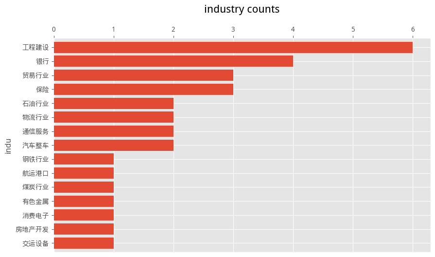

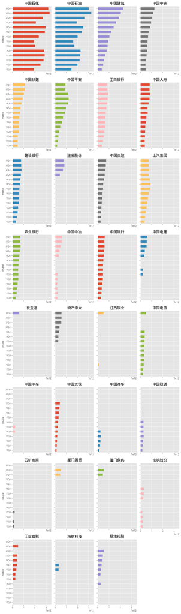

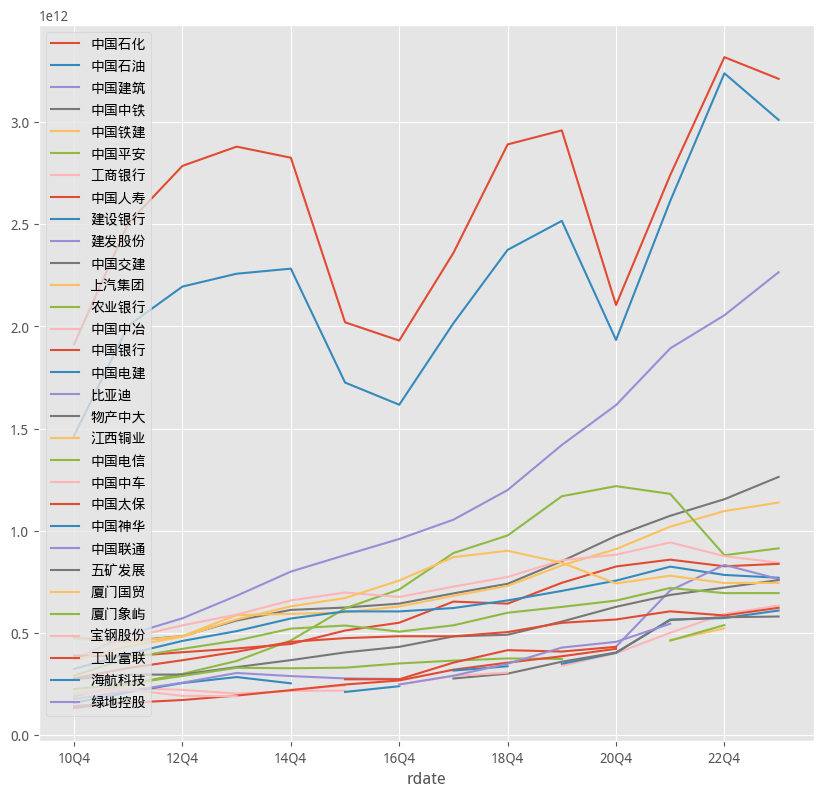

- 这些大巨头中，两桶油的波动相对较大，但地位无法动摇。
- 大金融中，平安的营收已经超过了工行，而且中国人寿和建设银行都相差不大了。

### 最近一年利润分布

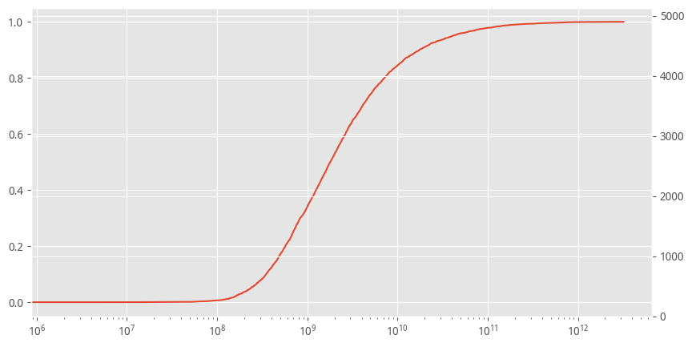

## TOP300

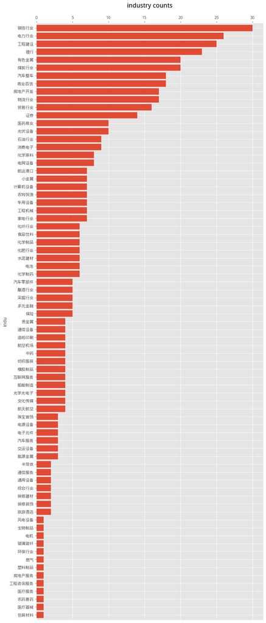

- 收入高的行业集中在钢铁、电力、银行等。

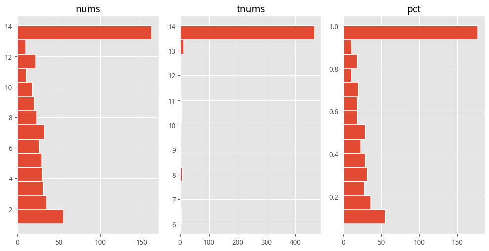

- 超过150家公司长期上榜。
- 能上榜的公司都是成立比较早的公司。大多是在2010年以前成立的。

1

[中国石化](https://data.eastmoney.com/stockdata/600028.html)

2

[中国石油](https://data.eastmoney.com/stockdata/601857.html)

3

[中国建筑](https://data.eastmoney.com/stockdata/601668.html)

4

[中国太保](https://data.eastmoney.com/stockdata/601601.html)

5

[中国中铁](https://data.eastmoney.com/stockdata/601390.html)

6

[中国铁建](https://data.eastmoney.com/stockdata/601186.html)

7

[中国平安](https://data.eastmoney.com/stockdata/601318.html)

8

[工商银行](https://data.eastmoney.com/stockdata/601398.html)

9

[中国人寿](https://data.eastmoney.com/stockdata/601628.html)

10

[上海医药](https://data.eastmoney.com/stockdata/601607.html)

11

[海尔智家](https://data.eastmoney.com/stockdata/600690.html)

12

[上海建工](https://data.eastmoney.com/stockdata/600170.html)

13

[荣盛石化](https://data.eastmoney.com/stockdata/002493.html)

14

[紫金矿业](https://data.eastmoney.com/stockdata/601899.html)

15

[保利发展](https://data.eastmoney.com/stockdata/600048.html)

16

[宝钢股份](https://data.eastmoney.com/stockdata/600019.html)

17

[中国神华](https://data.eastmoney.com/stockdata/601088.html)

18

[邮储银行](https://data.eastmoney.com/stockdata/601658.html)

19

[招商银行](https://data.eastmoney.com/stockdata/600036.html)

20

[华菱钢铁](https://data.eastmoney.com/stockdata/000932.html)

21

[华能国际](https://data.eastmoney.com/stockdata/600011.html)

22

[交通银行](https://data.eastmoney.com/stockdata/601328.html)

23

[兖矿能源](https://data.eastmoney.com/stockdata/600188.html)

24

[南方航空](https://data.eastmoney.com/stockdata/600029.html)

25

[中国联通](https://data.eastmoney.com/stockdata/600050.html)

26

[美的集团](https://data.eastmoney.com/stockdata/000333.html)

27

[国电电力](https://data.eastmoney.com/stockdata/600795.html)

28

[中信银行](https://data.eastmoney.com/stockdata/601998.html)

29

[中煤能源](https://data.eastmoney.com/stockdata/601898.html)

30

[浙商中拓](https://data.eastmoney.com/stockdata/000906.html)

31

[格力电器](https://data.eastmoney.com/stockdata/000651.html)

32

[潍柴动力](https://data.eastmoney.com/stockdata/000338.html)

33

[兴业银行](https://data.eastmoney.com/stockdata/601166.html)

34

[中国铝业](https://data.eastmoney.com/stockdata/601600.html)

35

[中国中车](https://data.eastmoney.com/stockdata/601766.html)

36

[华域汽车](https://data.eastmoney.com/stockdata/600741.html)

37

[平安银行](https://data.eastmoney.com/stockdata/000001.html)

38

[陕西煤业](https://data.eastmoney.com/stockdata/601225.html)

39

[九州通](https://data.eastmoney.com/stockdata/600998.html)

40

[贵州茅台](https://data.eastmoney.com/stockdata/600519.html)

41

[长安汽车](https://data.eastmoney.com/stockdata/000625.html)

42

[广汽集团](https://data.eastmoney.com/stockdata/601238.html)

43

[通威股份](https://data.eastmoney.com/stockdata/600438.html)

44

[中集集团](https://data.eastmoney.com/stockdata/000039.html)

45

[伊利股份](https://data.eastmoney.com/stockdata/600887.html)

46

[中远海控](https://data.eastmoney.com/stockdata/601919.html)

47

[中国化学](https://data.eastmoney.com/stockdata/601117.html)

48

[万华化学](https://data.eastmoney.com/stockdata/600309.html)

49

[TCL科技](https://data.eastmoney.com/stockdata/000100.html)

50

[浦发银行](https://data.eastmoney.com/stockdata/600000.html)

51

[长城汽车](https://data.eastmoney.com/stockdata/601633.html)

52

[桐昆股份](https://data.eastmoney.com/stockdata/601233.html)

53

[海信家电](https://data.eastmoney.com/stockdata/000921.html)

54

[大秦铁路](https://data.eastmoney.com/stockdata/601006.html)

55

[远大控股](https://data.eastmoney.com/stockdata/000626.html)

56

[金隅集团](https://data.eastmoney.com/stockdata/601992.html)

57

[太钢不锈](https://data.eastmoney.com/stockdata/000825.html)

58

[中国外运](https://data.eastmoney.com/stockdata/601598.html)

59

[马钢股份](https://data.eastmoney.com/stockdata/600808.html)

60

[特变电工](https://data.eastmoney.com/stockdata/600089.html)

61

[四川长虹](https://data.eastmoney.com/stockdata/600839.html)

62

[恒逸石化](https://data.eastmoney.com/stockdata/000703.html)

63

[铜陵有色](https://data.eastmoney.com/stockdata/000630.html)

64

[海螺水泥](https://data.eastmoney.com/stockdata/600585.html)

65

[民生银行](https://data.eastmoney.com/stockdata/600016.html)

66

[光大银行](https://data.eastmoney.com/stockdata/601818.html)

67

[中国国航](https://data.eastmoney.com/stockdata/601111.html)

68

[海大集团](https://data.eastmoney.com/stockdata/002311.html)

69

[首钢股份](https://data.eastmoney.com/stockdata/000959.html)

70

[云南铜业](https://data.eastmoney.com/stockdata/000878.html)

71

[华电国际](https://data.eastmoney.com/stockdata/600027.html)

72

[上海电气](https://data.eastmoney.com/stockdata/601727.html)

73

[鞍钢股份](https://data.eastmoney.com/stockdata/000898.html)

74

[中国东航](https://data.eastmoney.com/stockdata/600115.html)

75

[金地集团](https://data.eastmoney.com/stockdata/600383.html)

76

[徐工机械](https://data.eastmoney.com/stockdata/000425.html)

77

[上海石化](https://data.eastmoney.com/stockdata/600688.html)

78

[华夏银行](https://data.eastmoney.com/stockdata/600015.html)

79

[天音控股](https://data.eastmoney.com/stockdata/000829.html)

80

[浙能电力](https://data.eastmoney.com/stockdata/600023.html)

81

[中兴通讯](https://data.eastmoney.com/stockdata/000063.html)

82

[大唐发电](https://data.eastmoney.com/stockdata/601991.html)

83

[河钢股份](https://data.eastmoney.com/stockdata/000709.html)

84

[南钢股份](https://data.eastmoney.com/stockdata/600282.html)

85

[环旭电子](https://data.eastmoney.com/stockdata/601231.html)

86

[东方电气](https://data.eastmoney.com/stockdata/600875.html)

87

[ST易购](https://data.eastmoney.com/stockdata/002024.html)

88

[中金黄金](https://data.eastmoney.com/stockdata/600489.html)

89

[山煤国际](https://data.eastmoney.com/stockdata/600546.html)

90

[上港集团](https://data.eastmoney.com/stockdata/600018.html)

91

[一汽解放](https://data.eastmoney.com/stockdata/000800.html)

92

[云南白药](https://data.eastmoney.com/stockdata/000538.html)

93

[新华保险](https://data.eastmoney.com/stockdata/601336.html)

94

[老凤祥](https://data.eastmoney.com/stockdata/600612.html)

95

[厦门信达](https://data.eastmoney.com/stockdata/000701.html)

96

[包钢股份](https://data.eastmoney.com/stockdata/600010.html)

97

[云天化](https://data.eastmoney.com/stockdata/600096.html)

98

[中国中免](https://data.eastmoney.com/stockdata/601888.html)

99

[新钢股份](https://data.eastmoney.com/stockdata/600782.html)

100

[海亮股份](https://data.eastmoney.com/stockdata/002203.html)

101

[长江电力](https://data.eastmoney.com/stockdata/600900.html)

102

[永辉超市](https://data.eastmoney.com/stockdata/601933.html)

103

[五矿发展](https://data.eastmoney.com/stockdata/600058.html)

104

[石化油服](https://data.eastmoney.com/stockdata/600871.html)

105

[柳钢股份](https://data.eastmoney.com/stockdata/601003.html)

106

[北京银行](https://data.eastmoney.com/stockdata/601169.html)

107

[中储股份](https://data.eastmoney.com/stockdata/600787.html)

108

[三一重工](https://data.eastmoney.com/stockdata/600031.html)

109

[隧道股份](https://data.eastmoney.com/stockdata/600820.html)

110

[江苏银行](https://data.eastmoney.com/stockdata/600919.html)

111

[中国核电](https://data.eastmoney.com/stockdata/601985.html)

112

[国药一致](https://data.eastmoney.com/stockdata/000028.html)

113

[爱施德](https://data.eastmoney.com/stockdata/002416.html)

114

[山东钢铁](https://data.eastmoney.com/stockdata/600022.html)

115

[温氏股份](https://data.eastmoney.com/stockdata/300498.html)

116

[农业银行](https://data.eastmoney.com/stockdata/601288.html)

117

[上汽集团](https://data.eastmoney.com/stockdata/600104.html)

118

[中国交建](https://data.eastmoney.com/stockdata/601800.html)

119

[中国中冶](https://data.eastmoney.com/stockdata/601618.html)

120

[建发股份](https://data.eastmoney.com/stockdata/600153.html)

121

[江西铜业](https://data.eastmoney.com/stockdata/600362.html)

122

[厦门象屿](https://data.eastmoney.com/stockdata/600057.html)

123

[厦门国贸](https://data.eastmoney.com/stockdata/600755.html)

124

[中国电信](https://data.eastmoney.com/stockdata/601728.html)

125

[物产中大](https://data.eastmoney.com/stockdata/600704.html)

126

[金发科技](https://data.eastmoney.com/stockdata/600143.html)

127

[国机汽车](https://data.eastmoney.com/stockdata/600335.html)

128

[西部矿业](https://data.eastmoney.com/stockdata/601168.html)

129

[新兴铸管](https://data.eastmoney.com/stockdata/000778.html)

130

[首开股份](https://data.eastmoney.com/stockdata/600376.html)

131

[中联重科](https://data.eastmoney.com/stockdata/000157.html)

132

[中航西飞](https://data.eastmoney.com/stockdata/000768.html)

133

[华东医药](https://data.eastmoney.com/stockdata/000963.html)

134

[华谊集团](https://data.eastmoney.com/stockdata/600623.html)

135

[安阳钢铁](https://data.eastmoney.com/stockdata/600569.html)

136

[锡业股份](https://data.eastmoney.com/stockdata/000960.html)

137

[上海银行](https://data.eastmoney.com/stockdata/601229.html)

138

[中化国际](https://data.eastmoney.com/stockdata/600500.html)

139

[海信视像](https://data.eastmoney.com/stockdata/600060.html)

140

[双汇发展](https://data.eastmoney.com/stockdata/000895.html)

141

[金风科技](https://data.eastmoney.com/stockdata/002202.html)

142

[南京医药](https://data.eastmoney.com/stockdata/600713.html)

143

[山东黄金](https://data.eastmoney.com/stockdata/600547.html)

144

[中信证券](https://data.eastmoney.com/stockdata/600030.html)

145

[豫园股份](https://data.eastmoney.com/stockdata/600655.html)

146

[本钢板材](https://data.eastmoney.com/stockdata/000761.html)

147

[国投电力](https://data.eastmoney.com/stockdata/600886.html)

148

[福田汽车](https://data.eastmoney.com/stockdata/600166.html)

149

[杭钢股份](https://data.eastmoney.com/stockdata/600126.html)

150

[山西焦煤](https://data.eastmoney.com/stockdata/000983.html)

151

[酒钢宏兴](https://data.eastmoney.com/stockdata/600307.html)

152

[龙源电力](https://data.eastmoney.com/stockdata/001289.html)

153

[建设银行](https://data.eastmoney.com/stockdata/601939.html)

154

[重庆建工](https://data.eastmoney.com/stockdata/600939.html)

155

[江淮汽车](https://data.eastmoney.com/stockdata/600418.html)

156

[比亚迪](https://data.eastmoney.com/stockdata/002594.html)

157

[中国电建](https://data.eastmoney.com/stockdata/601669.html)

158

[中国银行](https://data.eastmoney.com/stockdata/601988.html)

159

[中国重工](https://data.eastmoney.com/stockdata/601989.html)

160

[中材国际](https://data.eastmoney.com/stockdata/600970.html)

161

[华锦股份](https://data.eastmoney.com/stockdata/000059.html)

162

[广州发展](https://data.eastmoney.com/stockdata/600098.html)

```
大金融：19 | 占比：0.11728395061728392
```

1

[中国石化](https://data.eastmoney.com/stockdata/600028.html)

2

[中国石油](https://data.eastmoney.com/stockdata/601857.html)

3

[中国建筑](https://data.eastmoney.com/stockdata/601668.html)

4

[中国太保](https://data.eastmoney.com/stockdata/601601.html)

5

[中国中铁](https://data.eastmoney.com/stockdata/601390.html)

6

[中国铁建](https://data.eastmoney.com/stockdata/601186.html)

7

[中国平安](https://data.eastmoney.com/stockdata/601318.html)

8

[中国人寿](https://data.eastmoney.com/stockdata/601628.html)

9

[上海医药](https://data.eastmoney.com/stockdata/601607.html)

10

[海尔智家](https://data.eastmoney.com/stockdata/600690.html)

11

[上海建工](https://data.eastmoney.com/stockdata/600170.html)

12

[荣盛石化](https://data.eastmoney.com/stockdata/002493.html)

13

[紫金矿业](https://data.eastmoney.com/stockdata/601899.html)

14

[保利发展](https://data.eastmoney.com/stockdata/600048.html)

15

[宝钢股份](https://data.eastmoney.com/stockdata/600019.html)

16

[中国神华](https://data.eastmoney.com/stockdata/601088.html)

17

[华菱钢铁](https://data.eastmoney.com/stockdata/000932.html)

18

[华能国际](https://data.eastmoney.com/stockdata/600011.html)

19

[兖矿能源](https://data.eastmoney.com/stockdata/600188.html)

20

[南方航空](https://data.eastmoney.com/stockdata/600029.html)

21

[中国联通](https://data.eastmoney.com/stockdata/600050.html)

22

[美的集团](https://data.eastmoney.com/stockdata/000333.html)

23

[国电电力](https://data.eastmoney.com/stockdata/600795.html)

24

[中煤能源](https://data.eastmoney.com/stockdata/601898.html)

25

[浙商中拓](https://data.eastmoney.com/stockdata/000906.html)

26

[格力电器](https://data.eastmoney.com/stockdata/000651.html)

27

[潍柴动力](https://data.eastmoney.com/stockdata/000338.html)

28

[中国铝业](https://data.eastmoney.com/stockdata/601600.html)

29

[中国中车](https://data.eastmoney.com/stockdata/601766.html)

30

[华域汽车](https://data.eastmoney.com/stockdata/600741.html)

31

[陕西煤业](https://data.eastmoney.com/stockdata/601225.html)

32

[九州通](https://data.eastmoney.com/stockdata/600998.html)

33

[贵州茅台](https://data.eastmoney.com/stockdata/600519.html)

34

[长安汽车](https://data.eastmoney.com/stockdata/000625.html)

35

[广汽集团](https://data.eastmoney.com/stockdata/601238.html)

36

[通威股份](https://data.eastmoney.com/stockdata/600438.html)

37

[中集集团](https://data.eastmoney.com/stockdata/000039.html)

38

[伊利股份](https://data.eastmoney.com/stockdata/600887.html)

39

[中远海控](https://data.eastmoney.com/stockdata/601919.html)

40

[中国化学](https://data.eastmoney.com/stockdata/601117.html)

41

[万华化学](https://data.eastmoney.com/stockdata/600309.html)

42

[TCL科技](https://data.eastmoney.com/stockdata/000100.html)

43

[长城汽车](https://data.eastmoney.com/stockdata/601633.html)

44

[桐昆股份](https://data.eastmoney.com/stockdata/601233.html)

45

[海信家电](https://data.eastmoney.com/stockdata/000921.html)

46

[大秦铁路](https://data.eastmoney.com/stockdata/601006.html)

47

[远大控股](https://data.eastmoney.com/stockdata/000626.html)

48

[金隅集团](https://data.eastmoney.com/stockdata/601992.html)

49

[太钢不锈](https://data.eastmoney.com/stockdata/000825.html)

50

[中国外运](https://data.eastmoney.com/stockdata/601598.html)

51

[马钢股份](https://data.eastmoney.com/stockdata/600808.html)

52

[特变电工](https://data.eastmoney.com/stockdata/600089.html)

53

[四川长虹](https://data.eastmoney.com/stockdata/600839.html)

54

[恒逸石化](https://data.eastmoney.com/stockdata/000703.html)

55

[铜陵有色](https://data.eastmoney.com/stockdata/000630.html)

56

[海螺水泥](https://data.eastmoney.com/stockdata/600585.html)

57

[中国国航](https://data.eastmoney.com/stockdata/601111.html)

58

[海大集团](https://data.eastmoney.com/stockdata/002311.html)

59

[首钢股份](https://data.eastmoney.com/stockdata/000959.html)

60

[云南铜业](https://data.eastmoney.com/stockdata/000878.html)

61

[华电国际](https://data.eastmoney.com/stockdata/600027.html)

62

[上海电气](https://data.eastmoney.com/stockdata/601727.html)

63

[鞍钢股份](https://data.eastmoney.com/stockdata/000898.html)

64

[中国东航](https://data.eastmoney.com/stockdata/600115.html)

65

[金地集团](https://data.eastmoney.com/stockdata/600383.html)

66

[徐工机械](https://data.eastmoney.com/stockdata/000425.html)

67

[上海石化](https://data.eastmoney.com/stockdata/600688.html)

68

[天音控股](https://data.eastmoney.com/stockdata/000829.html)

69

[浙能电力](https://data.eastmoney.com/stockdata/600023.html)

70

[中兴通讯](https://data.eastmoney.com/stockdata/000063.html)

71

[大唐发电](https://data.eastmoney.com/stockdata/601991.html)

72

[河钢股份](https://data.eastmoney.com/stockdata/000709.html)

73

[南钢股份](https://data.eastmoney.com/stockdata/600282.html)

74

[环旭电子](https://data.eastmoney.com/stockdata/601231.html)

75

[东方电气](https://data.eastmoney.com/stockdata/600875.html)

76

[ST易购](https://data.eastmoney.com/stockdata/002024.html)

77

[中金黄金](https://data.eastmoney.com/stockdata/600489.html)

78

[山煤国际](https://data.eastmoney.com/stockdata/600546.html)

79

[上港集团](https://data.eastmoney.com/stockdata/600018.html)

80

[一汽解放](https://data.eastmoney.com/stockdata/000800.html)

81

[云南白药](https://data.eastmoney.com/stockdata/000538.html)

82

[老凤祥](https://data.eastmoney.com/stockdata/600612.html)

83

[厦门信达](https://data.eastmoney.com/stockdata/000701.html)

84

[包钢股份](https://data.eastmoney.com/stockdata/600010.html)

85

[云天化](https://data.eastmoney.com/stockdata/600096.html)

86

[中国中免](https://data.eastmoney.com/stockdata/601888.html)

87

[新钢股份](https://data.eastmoney.com/stockdata/600782.html)

88

[海亮股份](https://data.eastmoney.com/stockdata/002203.html)

89

[长江电力](https://data.eastmoney.com/stockdata/600900.html)

90

[永辉超市](https://data.eastmoney.com/stockdata/601933.html)

91

[五矿发展](https://data.eastmoney.com/stockdata/600058.html)

92

[石化油服](https://data.eastmoney.com/stockdata/600871.html)

93

[柳钢股份](https://data.eastmoney.com/stockdata/601003.html)

94

[中储股份](https://data.eastmoney.com/stockdata/600787.html)

95

[三一重工](https://data.eastmoney.com/stockdata/600031.html)

96

[隧道股份](https://data.eastmoney.com/stockdata/600820.html)

97

[中国核电](https://data.eastmoney.com/stockdata/601985.html)

98

[国药一致](https://data.eastmoney.com/stockdata/000028.html)

99

[爱施德](https://data.eastmoney.com/stockdata/002416.html)

100

[山东钢铁](https://data.eastmoney.com/stockdata/600022.html)

101

[温氏股份](https://data.eastmoney.com/stockdata/300498.html)

102

[上汽集团](https://data.eastmoney.com/stockdata/600104.html)

103

[中国交建](https://data.eastmoney.com/stockdata/601800.html)

104

[中国中冶](https://data.eastmoney.com/stockdata/601618.html)

105

[建发股份](https://data.eastmoney.com/stockdata/600153.html)

106

[江西铜业](https://data.eastmoney.com/stockdata/600362.html)

107

[厦门象屿](https://data.eastmoney.com/stockdata/600057.html)

108

[厦门国贸](https://data.eastmoney.com/stockdata/600755.html)

109

[中国电信](https://data.eastmoney.com/stockdata/601728.html)

110

[物产中大](https://data.eastmoney.com/stockdata/600704.html)

111

[金发科技](https://data.eastmoney.com/stockdata/600143.html)

112

[国机汽车](https://data.eastmoney.com/stockdata/600335.html)

113

[西部矿业](https://data.eastmoney.com/stockdata/601168.html)

114

[新兴铸管](https://data.eastmoney.com/stockdata/000778.html)

115

[首开股份](https://data.eastmoney.com/stockdata/600376.html)

116

[中联重科](https://data.eastmoney.com/stockdata/000157.html)

117

[中航西飞](https://data.eastmoney.com/stockdata/000768.html)

118

[华东医药](https://data.eastmoney.com/stockdata/000963.html)

119

[华谊集团](https://data.eastmoney.com/stockdata/600623.html)

120

[安阳钢铁](https://data.eastmoney.com/stockdata/600569.html)

121

[锡业股份](https://data.eastmoney.com/stockdata/000960.html)

122

[中化国际](https://data.eastmoney.com/stockdata/600500.html)

123

[海信视像](https://data.eastmoney.com/stockdata/600060.html)

124

[双汇发展](https://data.eastmoney.com/stockdata/000895.html)

125

[金风科技](https://data.eastmoney.com/stockdata/002202.html)

126

[南京医药](https://data.eastmoney.com/stockdata/600713.html)

127

[山东黄金](https://data.eastmoney.com/stockdata/600547.html)

128

[豫园股份](https://data.eastmoney.com/stockdata/600655.html)

129

[本钢板材](https://data.eastmoney.com/stockdata/000761.html)

130

[国投电力](https://data.eastmoney.com/stockdata/600886.html)

131

[福田汽车](https://data.eastmoney.com/stockdata/600166.html)

132

[杭钢股份](https://data.eastmoney.com/stockdata/600126.html)

133

[山西焦煤](https://data.eastmoney.com/stockdata/000983.html)

134

[酒钢宏兴](https://data.eastmoney.com/stockdata/600307.html)

135

[龙源电力](https://data.eastmoney.com/stockdata/001289.html)

136

[重庆建工](https://data.eastmoney.com/stockdata/600939.html)

137

[江淮汽车](https://data.eastmoney.com/stockdata/600418.html)

138

[比亚迪](https://data.eastmoney.com/stockdata/002594.html)

139

[中国电建](https://data.eastmoney.com/stockdata/601669.html)

140

[中国重工](https://data.eastmoney.com/stockdata/601989.html)

141

[中材国际](https://data.eastmoney.com/stockdata/600970.html)

142

[华锦股份](https://data.eastmoney.com/stockdata/000059.html)

143

[广州发展](https://data.eastmoney.com/stockdata/600098.html)

## 增长情况

- 选择了有6期以上报告的公司，测试其近5年利润增长的夏普指数平均值，从高到低排列。

### 总体情况

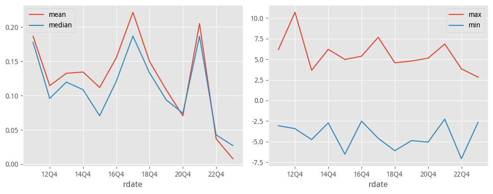

- 增长下滑。均值和中位数都创历史新低。
- 极值缩小。

### 增长排名

|  | cname | nums | tnums | pct |
| --- | --- | --- | --- | --- |
| 0 | 岩石股份 | 9 | 13 | 0.692308 |
| 1 | 复洁环保 | 6 | 10 | 0.600000 |
| 2 | 国联股份 | 6 | 11 | 0.545455 |
| 3 | 天下秀 | 6 | 13 | 0.461538 |
| 4 | 华海清科 | 6 | 6 | 1.000000 |
| 5 | *ST中迪 | 6 | 13 | 0.461538 |
| 6 | 益生股份 | 6 | 13 | 0.461538 |
| 7 | ST天龙 | 6 | 13 | 0.461538 |
| 8 | 长川科技 | 6 | 11 | 0.545455 |
| 9 | 明德生物 | 6 | 12 | 0.500000 |
| 10 | 固德威 | 6 | 10 | 0.600000 |
| 11 | 康乐卫士 | 6 | 10 | 0.600000 |
| 12 | 百诚医药 | 6 | 10 | 0.600000 |
| 13 | 荣丰控股 | 6 | 13 | 0.461538 |
| 14 | 上海钢联 | 6 | 13 | 0.461538 |
| 15 | 天源环保 | 6 | 11 | 0.545455 |
| 16 | 三元生物 | 5 | 10 | 0.500000 |
| 17 | 爱旭股份 | 5 | 13 | 0.384615 |
| 18 | 建元信托 | 5 | 13 | 0.384615 |
| 19 | 奥特维 | 5 | 10 | 0.500000 |

### 最近一年增长情况

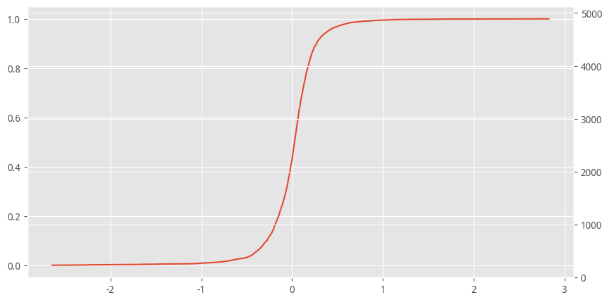

- 2023年，超过4成的上市公司没能实现营业收入增长。

### 夏普指数

- 夏普指数衡量增长的质量，比单纯看增长率要好一点。
- 以下是近五年夏普指数平均后的前300排名。

1

[金山办公](https://data.eastmoney.com/stockdata/688111.html)

2

[心脉医疗](https://data.eastmoney.com/stockdata/688016.html)

3

[欧普康视](https://data.eastmoney.com/stockdata/300595.html)

4

[南网能源](https://data.eastmoney.com/stockdata/003035.html)

5

[爱迪特](https://data.eastmoney.com/stockdata/301580.html)

6

[安恒信息](https://data.eastmoney.com/stockdata/688023.html)

7

[航天宏图](https://data.eastmoney.com/stockdata/688066.html)

8

[爱博医疗](https://data.eastmoney.com/stockdata/688050.html)

9

[康龙化成](https://data.eastmoney.com/stockdata/300759.html)

10

[普门科技](https://data.eastmoney.com/stockdata/688389.html)

11

[艾隆科技](https://data.eastmoney.com/stockdata/688329.html)

12

[晨光股份](https://data.eastmoney.com/stockdata/603899.html)

13

[安琪酵母](https://data.eastmoney.com/stockdata/600298.html)

14

[一心堂](https://data.eastmoney.com/stockdata/002727.html)

15

[致远互联](https://data.eastmoney.com/stockdata/688369.html)

16

[福昕软件](https://data.eastmoney.com/stockdata/688095.html)

17

[利安隆](https://data.eastmoney.com/stockdata/300596.html)

18

[苏文电能](https://data.eastmoney.com/stockdata/300982.html)

19

[东方电子](https://data.eastmoney.com/stockdata/000682.html)

20

[特发服务](https://data.eastmoney.com/stockdata/300917.html)

21

[九州通](https://data.eastmoney.com/stockdata/600998.html)

22

[大参林](https://data.eastmoney.com/stockdata/603233.html)

23

[派克新材](https://data.eastmoney.com/stockdata/605123.html)

24

[景旺电子](https://data.eastmoney.com/stockdata/603228.html)

25

[深信服](https://data.eastmoney.com/stockdata/300454.html)

26

[严牌股份](https://data.eastmoney.com/stockdata/301081.html)

27

[海天味业](https://data.eastmoney.com/stockdata/603288.html)

28

[安井食品](https://data.eastmoney.com/stockdata/603345.html)

29

[光库科技](https://data.eastmoney.com/stockdata/300620.html)

30

[山科智能](https://data.eastmoney.com/stockdata/300897.html)

31

[当虹科技](https://data.eastmoney.com/stockdata/688039.html)

32

[玉禾田](https://data.eastmoney.com/stockdata/300815.html)

33

[科林电气](https://data.eastmoney.com/stockdata/603050.html)

34

[星宇股份](https://data.eastmoney.com/stockdata/601799.html)

35

[广电计量](https://data.eastmoney.com/stockdata/002967.html)

36

[药明康德](https://data.eastmoney.com/stockdata/603259.html)

37

[漱玉平民](https://data.eastmoney.com/stockdata/301017.html)

38

[华测导航](https://data.eastmoney.com/stockdata/300627.html)

39

[智洋创新](https://data.eastmoney.com/stockdata/688191.html)

40

[密尔克卫](https://data.eastmoney.com/stockdata/603713.html)

41

[老百姓](https://data.eastmoney.com/stockdata/603883.html)

42

[利元亨](https://data.eastmoney.com/stockdata/688499.html)

43

[安图生物](https://data.eastmoney.com/stockdata/603658.html)

44

[中控技术](https://data.eastmoney.com/stockdata/688777.html)

45

[法本信息](https://data.eastmoney.com/stockdata/300925.html)

46

[爱朋医疗](https://data.eastmoney.com/stockdata/300753.html)

47

[药易购](https://data.eastmoney.com/stockdata/300937.html)

48

[佰仁医疗](https://data.eastmoney.com/stockdata/688198.html)

49

[拓斯达](https://data.eastmoney.com/stockdata/300607.html)

50

[航天电器](https://data.eastmoney.com/stockdata/002025.html)

51

[海晨股份](https://data.eastmoney.com/stockdata/300873.html)

52

[志特新材](https://data.eastmoney.com/stockdata/300986.html)

53

[华测检测](https://data.eastmoney.com/stockdata/300012.html)

54

[三峰环境](https://data.eastmoney.com/stockdata/601827.html)

55

[海尔生物](https://data.eastmoney.com/stockdata/688139.html)

56

[益丰药房](https://data.eastmoney.com/stockdata/603939.html)

57

[京北方](https://data.eastmoney.com/stockdata/002987.html)

58

[新产业](https://data.eastmoney.com/stockdata/300832.html)

59

[苏试试验](https://data.eastmoney.com/stockdata/300416.html)

60

[科大讯飞](https://data.eastmoney.com/stockdata/002230.html)

61

[科润智控](https://data.eastmoney.com/stockdata/834062.html)

62

[中际联合](https://data.eastmoney.com/stockdata/605305.html)

63

[四会富仕](https://data.eastmoney.com/stockdata/300852.html)

64

[亚香股份](https://data.eastmoney.com/stockdata/301220.html)

65

[奕瑞科技](https://data.eastmoney.com/stockdata/688301.html)

66

[祥源新材](https://data.eastmoney.com/stockdata/300980.html)

67

[地铁设计](https://data.eastmoney.com/stockdata/003013.html)

68

[五洲特纸](https://data.eastmoney.com/stockdata/605007.html)

69

[狄耐克](https://data.eastmoney.com/stockdata/300884.html)

70

[泰坦科技](https://data.eastmoney.com/stockdata/688133.html)

71

[南模生物](https://data.eastmoney.com/stockdata/688265.html)

72

[广州酒家](https://data.eastmoney.com/stockdata/603043.html)

73

[李子园](https://data.eastmoney.com/stockdata/605337.html)

74

[通策医疗](https://data.eastmoney.com/stockdata/600763.html)

75

[宇瞳光学](https://data.eastmoney.com/stockdata/300790.html)

76

[柳药集团](https://data.eastmoney.com/stockdata/603368.html)

77

[江丰电子](https://data.eastmoney.com/stockdata/300666.html)

78

[读客文化](https://data.eastmoney.com/stockdata/301025.html)

79

[众兴菌业](https://data.eastmoney.com/stockdata/002772.html)

80

[中航光电](https://data.eastmoney.com/stockdata/002179.html)

81

[德才股份](https://data.eastmoney.com/stockdata/605287.html)

82

[味知香](https://data.eastmoney.com/stockdata/605089.html)

83

[爱尔眼科](https://data.eastmoney.com/stockdata/300015.html)

84

[秦川物联](https://data.eastmoney.com/stockdata/688528.html)

85

[睿创微纳](https://data.eastmoney.com/stockdata/688002.html)

86

[爱玛科技](https://data.eastmoney.com/stockdata/603529.html)

87

[侨银股份](https://data.eastmoney.com/stockdata/002973.html)

88

[优宁维](https://data.eastmoney.com/stockdata/301166.html)

89

[宁波银行](https://data.eastmoney.com/stockdata/002142.html)

90

[卫宁健康](https://data.eastmoney.com/stockdata/300253.html)

91

[药石科技](https://data.eastmoney.com/stockdata/300725.html)

92

[爱美客](https://data.eastmoney.com/stockdata/300896.html)

93

[并行科技](https://data.eastmoney.com/stockdata/839493.html)

94

[汇川技术](https://data.eastmoney.com/stockdata/300124.html)

95

[深水海纳](https://data.eastmoney.com/stockdata/300961.html)

96

[亿联网络](https://data.eastmoney.com/stockdata/300628.html)

97

[中谷物流](https://data.eastmoney.com/stockdata/603565.html)

98

[金牌家居](https://data.eastmoney.com/stockdata/603180.html)

99

[桃李面包](https://data.eastmoney.com/stockdata/603866.html)

100

[皓元医药](https://data.eastmoney.com/stockdata/688131.html)

101

[新大正](https://data.eastmoney.com/stockdata/002968.html)

102

[南都物业](https://data.eastmoney.com/stockdata/603506.html)

103

[美力科技](https://data.eastmoney.com/stockdata/300611.html)

104

[虹软科技](https://data.eastmoney.com/stockdata/688088.html)

105

[安科生物](https://data.eastmoney.com/stockdata/300009.html)

106

[天阳科技](https://data.eastmoney.com/stockdata/300872.html)

107

[恒瑞医药](https://data.eastmoney.com/stockdata/600276.html)

108

[诺禾致源](https://data.eastmoney.com/stockdata/688315.html)

109

[长沙银行](https://data.eastmoney.com/stockdata/601577.html)

110

[晶雪节能](https://data.eastmoney.com/stockdata/301010.html)

111

[同力日升](https://data.eastmoney.com/stockdata/605286.html)

112

[云南白药](https://data.eastmoney.com/stockdata/000538.html)

113

[南京医药](https://data.eastmoney.com/stockdata/600713.html)

114

[坚朗五金](https://data.eastmoney.com/stockdata/002791.html)

115

[欧派家居](https://data.eastmoney.com/stockdata/603833.html)

116

[开能健康](https://data.eastmoney.com/stockdata/300272.html)

117

[京源环保](https://data.eastmoney.com/stockdata/688096.html)

118

[普蕊斯](https://data.eastmoney.com/stockdata/301257.html)

119

[中国建筑](https://data.eastmoney.com/stockdata/601668.html)

120

[格尔软件](https://data.eastmoney.com/stockdata/603232.html)

121

[光华科技](https://data.eastmoney.com/stockdata/002741.html)

122

[新媒股份](https://data.eastmoney.com/stockdata/300770.html)

123

[亿嘉和](https://data.eastmoney.com/stockdata/603666.html)

124

[盛视科技](https://data.eastmoney.com/stockdata/002990.html)

125

[亚士创能](https://data.eastmoney.com/stockdata/603378.html)

126

[微芯生物](https://data.eastmoney.com/stockdata/688321.html)

127

[正海生物](https://data.eastmoney.com/stockdata/300653.html)

128

[东方生物](https://data.eastmoney.com/stockdata/688298.html)

129

[阿拉丁](https://data.eastmoney.com/stockdata/688179.html)

130

[嘉事堂](https://data.eastmoney.com/stockdata/002462.html)

131

[健之佳](https://data.eastmoney.com/stockdata/605266.html)

132

[和而泰](https://data.eastmoney.com/stockdata/002402.html)

133

[西麦食品](https://data.eastmoney.com/stockdata/002956.html)

134

[拱东医疗](https://data.eastmoney.com/stockdata/605369.html)

135

[和元生物](https://data.eastmoney.com/stockdata/688238.html)

136

[山河药辅](https://data.eastmoney.com/stockdata/300452.html)

137

[甘源食品](https://data.eastmoney.com/stockdata/002991.html)

138

[金域医学](https://data.eastmoney.com/stockdata/603882.html)

139

[富祥药业](https://data.eastmoney.com/stockdata/300497.html)

140

[万兴科技](https://data.eastmoney.com/stockdata/300624.html)

141

[铂力特](https://data.eastmoney.com/stockdata/688333.html)

142

[三友医疗](https://data.eastmoney.com/stockdata/688085.html)

143

[裕同科技](https://data.eastmoney.com/stockdata/002831.html)

144

[青鸟消防](https://data.eastmoney.com/stockdata/002960.html)

145

[国瓷材料](https://data.eastmoney.com/stockdata/300285.html)

146

[振邦智能](https://data.eastmoney.com/stockdata/003028.html)

147

[安克创新](https://data.eastmoney.com/stockdata/300866.html)

148

[深圳瑞捷](https://data.eastmoney.com/stockdata/300977.html)

149

[昊帆生物](https://data.eastmoney.com/stockdata/301393.html)

150

[武汉蓝电](https://data.eastmoney.com/stockdata/830779.html)

151

[阳光电源](https://data.eastmoney.com/stockdata/300274.html)

152

[华如科技](https://data.eastmoney.com/stockdata/301302.html)

153

[东方雨虹](https://data.eastmoney.com/stockdata/002271.html)

154

[天宏锂电](https://data.eastmoney.com/stockdata/873152.html)

155

[金辰股份](https://data.eastmoney.com/stockdata/603396.html)

156

[捷昌驱动](https://data.eastmoney.com/stockdata/603583.html)

157

[小熊电器](https://data.eastmoney.com/stockdata/002959.html)

158

[广州港](https://data.eastmoney.com/stockdata/601228.html)

159

[浩欧博](https://data.eastmoney.com/stockdata/688656.html)

160

[起帆电缆](https://data.eastmoney.com/stockdata/605222.html)

161

[贵研铂业](https://data.eastmoney.com/stockdata/600459.html)

162

[泰格医药](https://data.eastmoney.com/stockdata/300347.html)

163

[上海建工](https://data.eastmoney.com/stockdata/600170.html)

164

[正元智慧](https://data.eastmoney.com/stockdata/300645.html)

165

[顺络电子](https://data.eastmoney.com/stockdata/002138.html)

166

[泛微网络](https://data.eastmoney.com/stockdata/603039.html)

167

[中天火箭](https://data.eastmoney.com/stockdata/003009.html)

168

[立讯精密](https://data.eastmoney.com/stockdata/002475.html)

169

[中瓷电子](https://data.eastmoney.com/stockdata/003031.html)

170

[驰诚股份](https://data.eastmoney.com/stockdata/834407.html)

171

[羚锐制药](https://data.eastmoney.com/stockdata/600285.html)

172

[科顺股份](https://data.eastmoney.com/stockdata/300737.html)

173

[奥海科技](https://data.eastmoney.com/stockdata/002993.html)

174

[海康威视](https://data.eastmoney.com/stockdata/002415.html)

175

[比音勒芬](https://data.eastmoney.com/stockdata/002832.html)

176

[健帆生物](https://data.eastmoney.com/stockdata/300529.html)

177

[中国太保](https://data.eastmoney.com/stockdata/601601.html)

178

[无锡银行](https://data.eastmoney.com/stockdata/600908.html)

179

[宝兰德](https://data.eastmoney.com/stockdata/688058.html)

180

[迈瑞医疗](https://data.eastmoney.com/stockdata/300760.html)

181

[欣旺达](https://data.eastmoney.com/stockdata/300207.html)

182

[丽珠集团](https://data.eastmoney.com/stockdata/000513.html)

183

[德源药业](https://data.eastmoney.com/stockdata/832735.html)

184

[八方股份](https://data.eastmoney.com/stockdata/603489.html)

185

[喜临门](https://data.eastmoney.com/stockdata/603008.html)

186

[招商蛇口](https://data.eastmoney.com/stockdata/001979.html)

187

[透景生命](https://data.eastmoney.com/stockdata/300642.html)

188

[博瑞医药](https://data.eastmoney.com/stockdata/688166.html)

189

[景嘉微](https://data.eastmoney.com/stockdata/300474.html)

190

[长虹能源](https://data.eastmoney.com/stockdata/836239.html)

191

[昭衍新药](https://data.eastmoney.com/stockdata/603127.html)

192

[宁波方正](https://data.eastmoney.com/stockdata/300998.html)

193

[三棵树](https://data.eastmoney.com/stockdata/603737.html)

194

[开普云](https://data.eastmoney.com/stockdata/688228.html)

195

[威海广泰](https://data.eastmoney.com/stockdata/002111.html)

196

[凯莱英](https://data.eastmoney.com/stockdata/002821.html)

197

[艾德生物](https://data.eastmoney.com/stockdata/300685.html)

198

[威星智能](https://data.eastmoney.com/stockdata/002849.html)

199

[回天新材](https://data.eastmoney.com/stockdata/300041.html)

200

[艾融软件](https://data.eastmoney.com/stockdata/830799.html)

201

[美迪西](https://data.eastmoney.com/stockdata/688202.html)

202

[迪安诊断](https://data.eastmoney.com/stockdata/300244.html)

203

[中国电建](https://data.eastmoney.com/stockdata/601669.html)

204

[国检集团](https://data.eastmoney.com/stockdata/603060.html)

205

[三诺生物](https://data.eastmoney.com/stockdata/300298.html)

206

[伊利股份](https://data.eastmoney.com/stockdata/600887.html)

207

[绿盟科技](https://data.eastmoney.com/stockdata/300369.html)

208

[依依股份](https://data.eastmoney.com/stockdata/001206.html)

209

[迈克生物](https://data.eastmoney.com/stockdata/300463.html)

210

[科华控股](https://data.eastmoney.com/stockdata/603161.html)

211

[首都在线](https://data.eastmoney.com/stockdata/300846.html)

212

[兴蓉环境](https://data.eastmoney.com/stockdata/000598.html)

213

[索菲亚](https://data.eastmoney.com/stockdata/002572.html)

214

[盐津铺子](https://data.eastmoney.com/stockdata/002847.html)

215

[维海德](https://data.eastmoney.com/stockdata/301318.html)

216

[克明食品](https://data.eastmoney.com/stockdata/002661.html)

217

[福龙马](https://data.eastmoney.com/stockdata/603686.html)

218

[风语筑](https://data.eastmoney.com/stockdata/603466.html)

219

[一鸣食品](https://data.eastmoney.com/stockdata/605179.html)

220

[红旗连锁](https://data.eastmoney.com/stockdata/002697.html)

221

[中富通](https://data.eastmoney.com/stockdata/300560.html)

222

[北特科技](https://data.eastmoney.com/stockdata/603009.html)

223

[燕塘乳业](https://data.eastmoney.com/stockdata/002732.html)

224

[值得买](https://data.eastmoney.com/stockdata/300785.html)

225

[中微公司](https://data.eastmoney.com/stockdata/688012.html)

226

[塞力医疗](https://data.eastmoney.com/stockdata/603716.html)

227

[国投智能](https://data.eastmoney.com/stockdata/300188.html)

228

[柏楚电子](https://data.eastmoney.com/stockdata/688188.html)

229

[贝仕达克](https://data.eastmoney.com/stockdata/300822.html)

230

[爱婴室](https://data.eastmoney.com/stockdata/603214.html)

231

[赛意信息](https://data.eastmoney.com/stockdata/300687.html)

232

[大地海洋](https://data.eastmoney.com/stockdata/301068.html)

233

[志邦家居](https://data.eastmoney.com/stockdata/603801.html)

234

[万德斯](https://data.eastmoney.com/stockdata/688178.html)

235

[斯达半导](https://data.eastmoney.com/stockdata/603290.html)

236

[和达科技](https://data.eastmoney.com/stockdata/688296.html)

237

[瑞联新材](https://data.eastmoney.com/stockdata/688550.html)

238

[湘佳股份](https://data.eastmoney.com/stockdata/002982.html)

239

[久远银海](https://data.eastmoney.com/stockdata/002777.html)

240

[长春高新](https://data.eastmoney.com/stockdata/000661.html)

241

[菲菱科思](https://data.eastmoney.com/stockdata/301191.html)

242

[中研股份](https://data.eastmoney.com/stockdata/688716.html)

243

[长阳科技](https://data.eastmoney.com/stockdata/688299.html)

244

[迈拓股份](https://data.eastmoney.com/stockdata/301006.html)

245

[浙江震元](https://data.eastmoney.com/stockdata/000705.html)

246

[阿石创](https://data.eastmoney.com/stockdata/300706.html)

247

[大博医疗](https://data.eastmoney.com/stockdata/002901.html)

248

[安博通](https://data.eastmoney.com/stockdata/688168.html)

249

[健康元](https://data.eastmoney.com/stockdata/600380.html)

250

[坤恒顺维](https://data.eastmoney.com/stockdata/688283.html)

251

[精测电子](https://data.eastmoney.com/stockdata/300567.html)

252

[吉冈精密](https://data.eastmoney.com/stockdata/836720.html)

253

[紫金矿业](https://data.eastmoney.com/stockdata/601899.html)

254

[凌志软件](https://data.eastmoney.com/stockdata/688588.html)

255

[海大集团](https://data.eastmoney.com/stockdata/002311.html)

256

[赢时胜](https://data.eastmoney.com/stockdata/300377.html)

257

[英特集团](https://data.eastmoney.com/stockdata/000411.html)

258

[浙江鼎力](https://data.eastmoney.com/stockdata/603338.html)

259

[大华股份](https://data.eastmoney.com/stockdata/002236.html)

260

[福立旺](https://data.eastmoney.com/stockdata/688678.html)

261

[亿纬锂能](https://data.eastmoney.com/stockdata/300014.html)

262

[可川科技](https://data.eastmoney.com/stockdata/603052.html)

263

[美亚光电](https://data.eastmoney.com/stockdata/002690.html)

264

[上海艾录](https://data.eastmoney.com/stockdata/301062.html)

265

[新风光](https://data.eastmoney.com/stockdata/688663.html)

266

[硅烷科技](https://data.eastmoney.com/stockdata/838402.html)

267

[新洁能](https://data.eastmoney.com/stockdata/605111.html)

268

[中国交建](https://data.eastmoney.com/stockdata/601800.html)

269

[梦百合](https://data.eastmoney.com/stockdata/603313.html)

270

[豪美新材](https://data.eastmoney.com/stockdata/002988.html)

271

[上海医药](https://data.eastmoney.com/stockdata/601607.html)

272

[品茗科技](https://data.eastmoney.com/stockdata/688109.html)

273

[德联集团](https://data.eastmoney.com/stockdata/002666.html)

274

[广咨国际](https://data.eastmoney.com/stockdata/836892.html)

275

[海峡环保](https://data.eastmoney.com/stockdata/603817.html)

276

[壹石通](https://data.eastmoney.com/stockdata/688733.html)

277

[赛伦生物](https://data.eastmoney.com/stockdata/688163.html)

278

[蒙泰高新](https://data.eastmoney.com/stockdata/300876.html)

279

[欧陆通](https://data.eastmoney.com/stockdata/300870.html)

280

[亚华电子](https://data.eastmoney.com/stockdata/301337.html)

281

[德业股份](https://data.eastmoney.com/stockdata/605117.html)

282

[杭电股份](https://data.eastmoney.com/stockdata/603618.html)

283

[鱼跃医疗](https://data.eastmoney.com/stockdata/002223.html)

284

[伟思医疗](https://data.eastmoney.com/stockdata/688580.html)

285

[亨通光电](https://data.eastmoney.com/stockdata/600487.html)

286

[太极股份](https://data.eastmoney.com/stockdata/002368.html)

287

[舜禹股份](https://data.eastmoney.com/stockdata/301519.html)

288

[天源迪科](https://data.eastmoney.com/stockdata/300047.html)

289

[杭可科技](https://data.eastmoney.com/stockdata/688006.html)

290

[江苏金租](https://data.eastmoney.com/stockdata/600901.html)

291

[中国科传](https://data.eastmoney.com/stockdata/601858.html)

292

[骏创科技](https://data.eastmoney.com/stockdata/833533.html)

293

[良信股份](https://data.eastmoney.com/stockdata/002706.html)

294

[宏裕包材](https://data.eastmoney.com/stockdata/837174.html)

295

[乐鑫科技](https://data.eastmoney.com/stockdata/688018.html)

296

[金宏气体](https://data.eastmoney.com/stockdata/688106.html)

297

[华熙生物](https://data.eastmoney.com/stockdata/688363.html)

298

[飞沃科技](https://data.eastmoney.com/stockdata/301232.html)

299

[长川科技](https://data.eastmoney.com/stockdata/300604.html)

300

[永辉超市](https://data.eastmoney.com/stockdata/601933.html)

## 利润金额和利润增长

13

[九州通](https://data.eastmoney.com/stockdata/600998.html)

4.41

9

[药明康德](https://data.eastmoney.com/stockdata/603259.html)

3.88

13

[宁波银行](https://data.eastmoney.com/stockdata/002142.html)

2.83

13

[恒瑞医药](https://data.eastmoney.com/stockdata/600276.html)

2.64

13

[云南白药](https://data.eastmoney.com/stockdata/000538.html)

2.63

13

[南京医药](https://data.eastmoney.com/stockdata/600713.html)

2.62

13

[中国建筑](https://data.eastmoney.com/stockdata/601668.html)

2.58

13

[阳光电源](https://data.eastmoney.com/stockdata/300274.html)

2.37

13

[东方雨虹](https://data.eastmoney.com/stockdata/002271.html)

2.36

13

[贵研铂业](https://data.eastmoney.com/stockdata/600459.html)

2.33

13

[上海建工](https://data.eastmoney.com/stockdata/600170.html)

2.32

13

[立讯精密](https://data.eastmoney.com/stockdata/002475.html)

2.30

13

[海康威视](https://data.eastmoney.com/stockdata/002415.html)

2.25

9

[迈瑞医疗](https://data.eastmoney.com/stockdata/300760.html)

2.24

13

[中国太保](https://data.eastmoney.com/stockdata/601601.html)

2.24

13

[欣旺达](https://data.eastmoney.com/stockdata/300207.html)

2.23

10

[招商蛇口](https://data.eastmoney.com/stockdata/001979.html)

2.20

13

[中国电建](https://data.eastmoney.com/stockdata/601669.html)

2.11

13

[伊利股份](https://data.eastmoney.com/stockdata/600887.html)

2.10

13

[紫金矿业](https://data.eastmoney.com/stockdata/601899.html)

2.00

13

[海大集团](https://data.eastmoney.com/stockdata/002311.html)

2.00

13

[亿纬锂能](https://data.eastmoney.com/stockdata/300014.html)

1.98

13

[英特集团](https://data.eastmoney.com/stockdata/000411.html)

1.98

13

[大华股份](https://data.eastmoney.com/stockdata/002236.html)

1.98

13

[中国交建](https://data.eastmoney.com/stockdata/601800.html)

1.96

13

[上海医药](https://data.eastmoney.com/stockdata/601607.html)

1.95

13

[亨通光电](https://data.eastmoney.com/stockdata/600487.html)

1.91

13

[永辉超市](https://data.eastmoney.com/stockdata/601933.html)

1.88

```
total: 28 | banks: 1 | non-banks: 27
```

13

[九州通](https://data.eastmoney.com/stockdata/600998.html)

4.41

9

[药明康德](https://data.eastmoney.com/stockdata/603259.html)

3.88

13

[恒瑞医药](https://data.eastmoney.com/stockdata/600276.html)

2.64

13

[云南白药](https://data.eastmoney.com/stockdata/000538.html)

2.63

13

[南京医药](https://data.eastmoney.com/stockdata/600713.html)

2.62

13

[中国建筑](https://data.eastmoney.com/stockdata/601668.html)

2.58

13

[阳光电源](https://data.eastmoney.com/stockdata/300274.html)

2.37

13

[东方雨虹](https://data.eastmoney.com/stockdata/002271.html)

2.36

13

[贵研铂业](https://data.eastmoney.com/stockdata/600459.html)

2.33

13

[上海建工](https://data.eastmoney.com/stockdata/600170.html)

2.32

13

[立讯精密](https://data.eastmoney.com/stockdata/002475.html)

2.30

13

[海康威视](https://data.eastmoney.com/stockdata/002415.html)

2.25

9

[迈瑞医疗](https://data.eastmoney.com/stockdata/300760.html)

2.24

13

[中国太保](https://data.eastmoney.com/stockdata/601601.html)

2.24

13

[欣旺达](https://data.eastmoney.com/stockdata/300207.html)

2.23

10

[招商蛇口](https://data.eastmoney.com/stockdata/001979.html)

2.20

13

[中国电建](https://data.eastmoney.com/stockdata/601669.html)

2.11

13

[伊利股份](https://data.eastmoney.com/stockdata/600887.html)

2.10

13

[紫金矿业](https://data.eastmoney.com/stockdata/601899.html)

2.00

13

[海大集团](https://data.eastmoney.com/stockdata/002311.html)

2.00

13

[亿纬锂能](https://data.eastmoney.com/stockdata/300014.html)

1.98

13

[英特集团](https://data.eastmoney.com/stockdata/000411.html)

1.98

13

[大华股份](https://data.eastmoney.com/stockdata/002236.html)

1.98

13

[中国交建](https://data.eastmoney.com/stockdata/601800.html)

1.96

13

[上海医药](https://data.eastmoney.com/stockdata/601607.html)

1.95

13

[亨通光电](https://data.eastmoney.com/stockdata/600487.html)

1.91

13

[永辉超市](https://data.eastmoney.com/stockdata/601933.html)

1.88